# Investigation of the Factors for Rising Housing Costs

A3

2022-08-03

## 1 Introduction

### 1.1 Background

With the increase in unaffordable housing, it has become a chronic social issue in Canada over the last two decades. The factors that contribute to rising housing costs have been in focus and hotly debated among policymakers and voters alike. We would like to measure the relative importance of the commonly referred contributors to the rising cost of housing: interest rate, immigration, earnings increases, and a general increase in consumer prices [3]. We will explore and quantify the significance of the predictors or drivers of rising housing prices above. Furthermore, by better understanding possible causes and predictors of the present-day problem, we aim to inform policymakers and their electorate on the most important issues underlying the unaffordable housing markets of metropolitan Canada.

### 1.2 Variables

[output not shown]

## 2 Analysis

### 2.1 Pre-Data Analysis

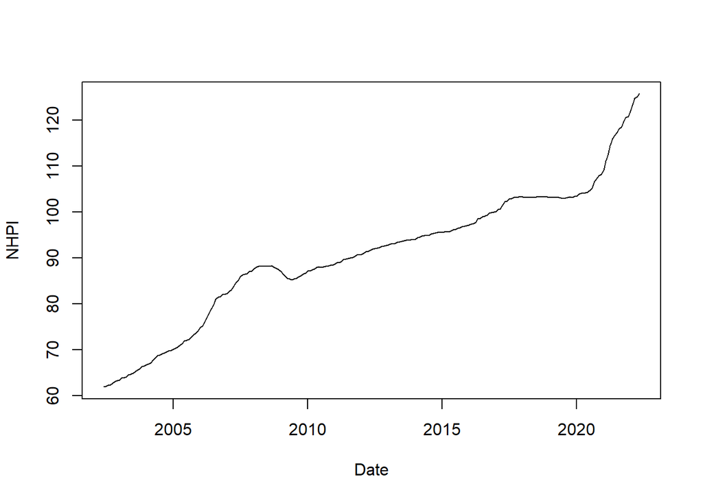

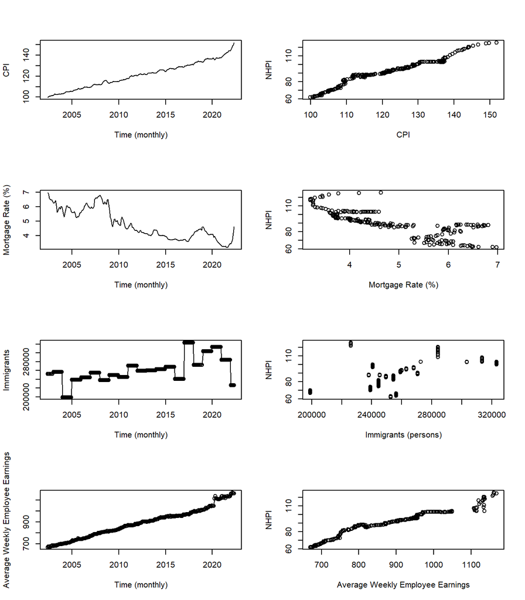

| Transformation | Sample correlation (r) |
| --- | --- |
| $\text{Interest}$ | -0.7978552 |
| $log(\text{Interest})$ | -0.8128942 |
| $(\text{Interest})^-1$ | 0.8199765 |
| $\text{Interest}^2$ | -0.7762884 |
| $(\text{Interest}-7)^2$ | 0.8253844 |

Because interest rates are mostly set by the Bank of Canada, the changes appear somewhat erratic. It seems like a quadratic curve centered around 7. Due to the lack of monthly data on immigration provided by Statistics Canada, the monthly data was imputed by applying the yearly data flatly across calendar years. The predictor variable itself doesn’t have a strong linear pattern, but seems to have been generally increasing over the last two decades.

We observe a sudden jump in the average weekly employee earnings. The jump happened in March 2020, and is likely due to the pandemic.

## 2.2 Collinearity

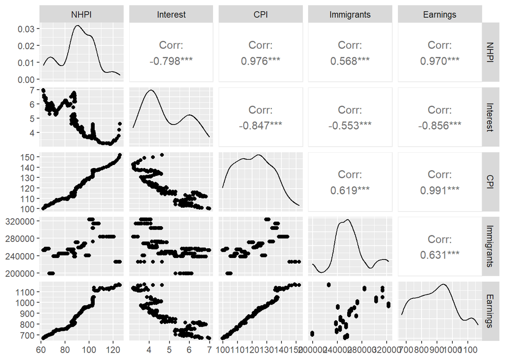

|  | VIF |
| --- | --- |
| Interest | 3.752 |
| CPI | 58.437 |
| Immigrants | 1.672 |
| Earnings | 63.187 |

We measured the collinearity in the dataset with VIF (Variance Inflation Factor). The VIFs of CPI and Earnings is larger than 10, and therefore, the collinearity between them may be a problem.

### 2.3.1 Model Selection with Exhaustive Search

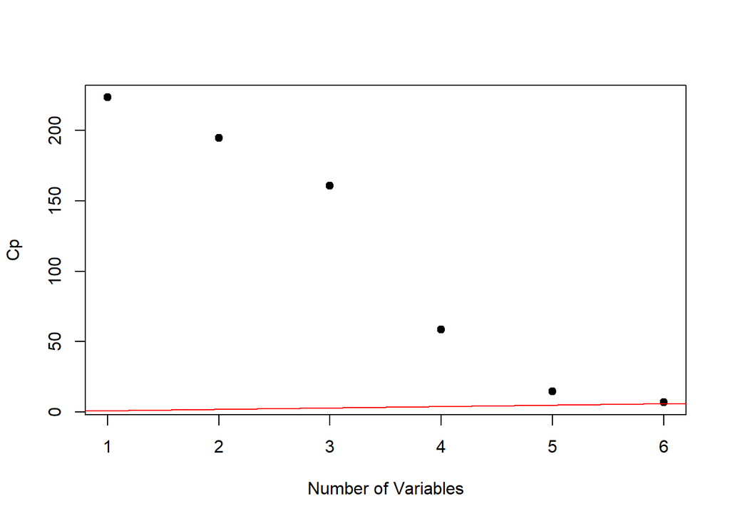

| p | $r^2$ | $r^2_{adj}$ | $C_p$ |
| --- | --- | --- | --- |
| 1 | 0.9522666 | 0.9520661 | 223.20787 |
| 2 | 0.9554736 | 0.9550978 | 194.35584 |
| 3 | 0.9592062 | 0.9586876 | 160.44748 |
| 4 | 0.9699909 | 0.9694801 | 58.69533 |
| 5 | 0.9747847 | 0.9742459 | 14.57800 |
| 6 | 0.9757803 | 0.9751566 | 7.00000 |

We chose the model with 6 predictor variables including the interaction term and the quadratic term because $C_6$ is very close to the corresponding value of $p$, and the model therefore appears the least unbiased.

We created 3 candidate models. full linear **Model 1**, **Model 2** with an interaction term between CPI and average weekly earnings, and **Model 3** with the same interaction term and a quadratic term for the mortgage rate. The quadratic term was added based on Figure 2, and the residual plots of the fully linear model, and the model with an interaction term.

|  | Estimate | Std. Error | t value | Pr(>\|t\|) |
| --- | --- | --- | --- | --- |
| (Intercept) | -52.1039140 | 6.3503810 | -8.204849 | 0.0000000 |
| Interest | 1.6062384 | 0.3581727 | 4.484536 | 0.0000114 |
| CPI | 0.9134636 | 0.1191467 | 7.666712 | 0.0000000 |
| Immigrants | -0.0000324 | 0.0000087 | -3.709042 | 0.0002597 |
| Earnings | 0.0370122 | 0.0114562 | 3.230756 | 0.0014113 |

|  | Estimate | Std. Error | t value | Pr(>\|t\|) |
| --- | --- | --- | --- | --- |
| (Intercept) | -183.1623129 | 12.5383819 | -14.608130 | 0 |
| Interest | 2.9667882 | 0.3110743 | 9.537234 | 0 |
| CPI | 1.7966471 | 0.1228930 | 14.619600 | 0 |
| Immigrants | -0.0000453 | 0.0000071 | -6.374004 | 0 |
| Earnings | 0.2010940 | 0.0170363 | 11.803844 | 0 |
| CPI:Earnings | -0.0011433 | 0.0000999 | -11.440228 | 0 |

|  | Estimate | Std. Error | t value | Pr(>\|t\|) |
| --- | --- | --- | --- | --- |
| (Intercept) | -173.4710111 | 12.2219078 | -14.193448 | 0.0000000 |
| Interest | -6.4194332 | 2.0742415 | -3.094834 | 0.0022101 |
| CPI | 2.0165623 | 0.1274021 | 15.828327 | 0.0000000 |
| Immigrants | -0.0000482 | 0.0000069 | -7.033372 | 0.0000000 |
| Earnings | 0.2025099 | 0.0163577 | 12.380118 | 0.0000000 |
| I(Interest^2) | 0.8988153 | 0.1965580 | 4.572773 | 0.0000078 |
| CPI:Earnings | -0.0012664 | 0.0000996 | -12.709211 | 0.0000000 |

The models appear excellent in terms of the significance of the predictor variables. However, they were based on a time series data, which is most likely serially correlated. Hence, we need to examine, and possibly correct for the possible autocorrelation in the data.

### 2.3.2 Serial Correlation

The standard assumptions of linear regression includes serial independence of data. The Durbin-Watson statistic was used to measure the serial correlation of our model [1].

The Durbin-Watson statistic for our model is 0.1225723, and which is close to 0 with a very small $p$ value, indicating high positive serial correlation. The standard errors of coefficients are underestimated if the data is positively serially correlated.

### 2.3.3 Newey-West Standard Errors

The standard errors of coefficients are underestimated due to the high serial correlation. Instead the Newey-West standard errors, both Heteorscedasticity and Autocorrelation (HAC), should be used instead [2]. The chosen delay truncation value is 12 intervals (months).

|  | Estimate | Std. Error | t value | Pr(>\|t\|) |
| --- | --- | --- | --- | --- |
| (Intercept) | -52.1039140 | 18.8291084 | -2.767200 | 0.0061041 |
| Interest | 1.6062384 | 1.2335760 | 1.302099 | 0.1941572 |
| CPI | 0.9134636 | 0.3422132 | 2.669282 | 0.0081314 |
| Immigrants | -0.0000324 | 0.0000276 | -1.175946 | 0.2408065 |
| Earnings | 0.0370122 | 0.0343642 | 1.077057 | 0.2825592 |

The significance of some of the variables appear much lower when corrected for autocorrelation, and most of them appear insignificant when corrected for serial correlation. This model is mostly based on the autocorrelation in the data.

|  | Estimate | Std. Error | t value | Pr(>\|t\|) |
| --- | --- | --- | --- | --- |
| (Intercept) | -183.1623129 | 37.5845399 | -4.873342 | 0.0000020 |
| Interest | 2.9667882 | 0.8128600 | 3.649815 | 0.0003237 |
| CPI | 1.7966471 | 0.3846929 | 4.670341 | 0.0000051 |
| Immigrants | -0.0000453 | 0.0000252 | -1.799818 | 0.0731775 |
| Earnings | 0.2010940 | 0.0490489 | 4.099865 | 0.0000570 |
| CPI:Earnings | -0.0011433 | 0.0003127 | -3.656415 | 0.0003159 |

When the interaction term is included, the significance of the predictor variables are improved overall. The increased complexity of the model better captures the significance of the predictor variables and their interactions.

|  | Estimate | Std. Error | t value | Pr(>\|t\|) |
| --- | --- | --- | --- | --- |
| (Intercept) | -173.4710111 | 35.6092516 | -4.871515 | 0.0000020 |
| Interest | -6.4194332 | 6.1070554 | -1.051150 | 0.2942785 |
| CPI | 2.0165623 | 0.3380983 | 5.964426 | 0.0000000 |
| Immigrants | -0.0000482 | 0.0000244 | -1.972527 | 0.0497320 |
| Earnings | 0.2025099 | 0.0465326 | 4.352004 | 0.0000202 |
| I(Interest^2) | 0.8988153 | 0.5527657 | 1.626033 | 0.1052943 |
| CPI:Earnings | -0.0012664 | 0.0002858 | -4.430721 | 0.0000145 |

The predictor variables remain significant even after the correction. The lag is set at 12 months. The significance of $\text{Interest}$ and $\text{Interest}^2$ is individually quite low, but cannot be discounted since the linear and quadratic terms may still be significant when combined.

### 2.3.4 Residuals

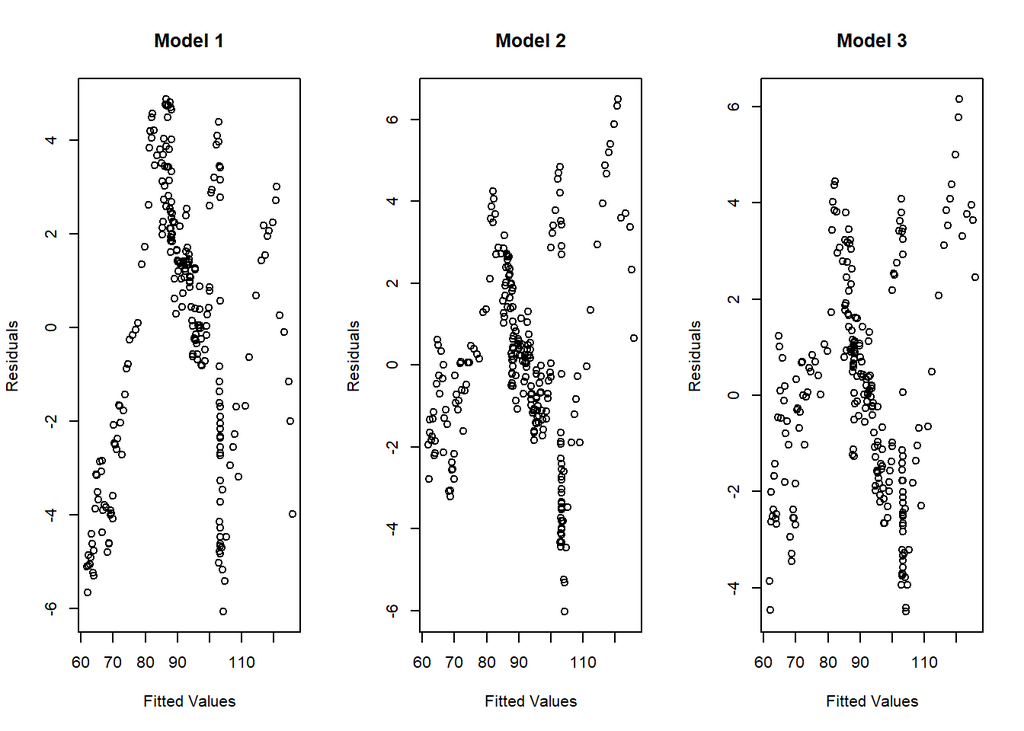

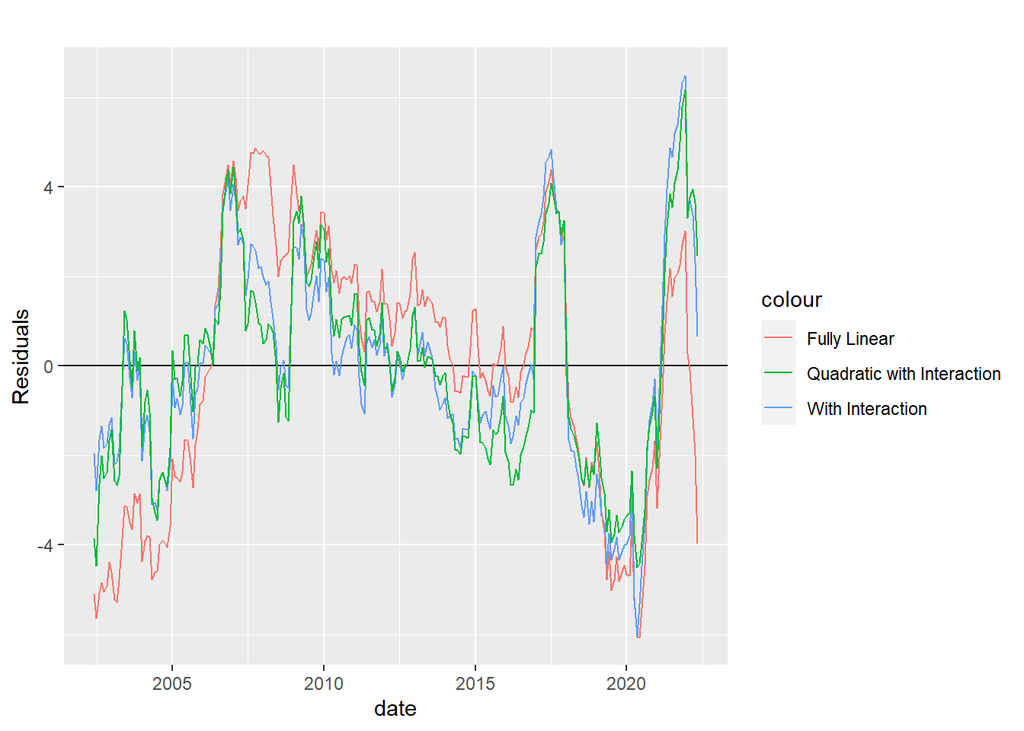

There seems to be patterns in residuals to the autorrelation in the form of a serial correlation in the data. The continuous patterns seem to arise from the fact that our data is a time series, and do not necessarily imply lack of linearizability. Still, we cannot explain with all variance in NHPI with the predictors here due to rapid, artificial shifts in variables such interest rates, which can change drastically based on the whims of the central bank. We may need more variables and average-over-time transformations for a more complete model that accounts for sudden shifts.

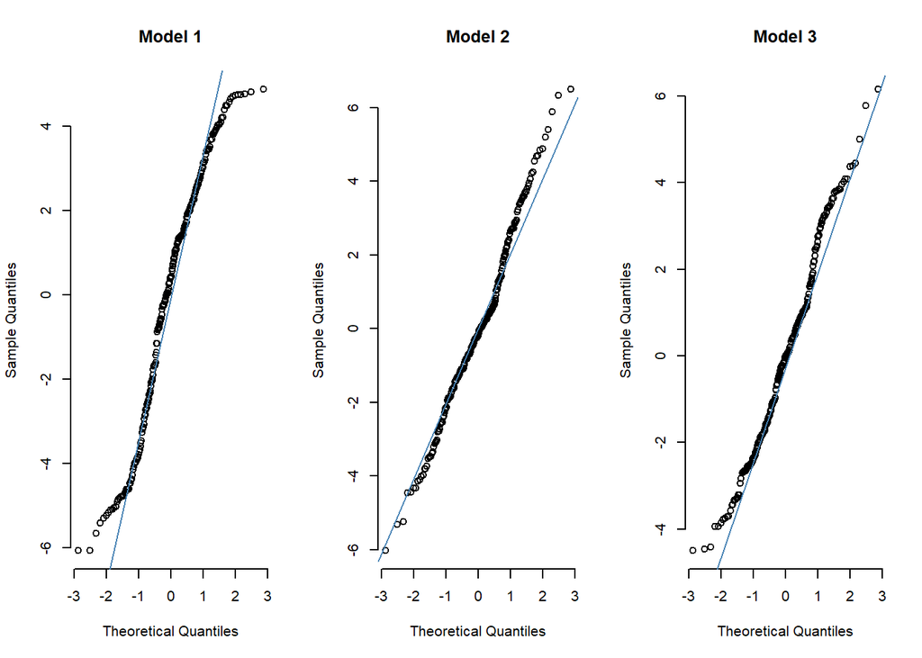

The error distribution of the fully linear model is light-tailed, and the normality-of-errors assumption may not hold. While The simplicity of the model is a positive attribute, the model is too light-tailed on the right side, and undermines the model’s value for making forecasts.

The distribution of the residual is heavy-tailed, but not extremely so. The normal error assumption seems to mostly hold.

### 2.3.5 Forecast Tests with a Holdout Set

We cannot do a cross-validation on a time series data. We instead train our model on the first 80% of the data, and test it on the last 20% of the data. The root mean square prediction errors are used to evaluate the three models.

| Model | RMSE |
| --- | --- |
| Model 1 | 1.426268 |
| Model 2 | 1.130076 |
| Model3 | 1.159623 |

The model with an interaction term seems to perform the best. However, our data is a time series, and the holdout sets necessarily include the most recent data, which tend to be the most important data points in time series models. Furthermore, because the most recent data involves the highly unusual period of the COVID-19 pandemic, it is unlikely that we can build a strong model while excluding the most recent 20% .

### 2.3.6 Akaike Information Criterion (AIC)

Because of the reasons discussed in the previous sections, tests using holdout sets may be misleading in evaluating the models. As a result, AIC is particularly valuable for choosing the best model among our three models.

| Model | AIC |
| --- | --- |
| Model 1 | 1205.517 |
| Model 2 | 1100.898 |
| Model3 | 1082.272 |

The quadratic model (Model 3) has the lowest AIC among the three models. It implies that the quadratic model has the smallest prediction error in general.

### 2.3.7 Forecasts Using Models

One major use of time series models is to forecast response variables in the future. In this section, we attempt to forecast NHPI for June and July 2022 with imputed values, and updated interest rates. All predictor variables were assumed to have remained the same since May except for the interest rate. The Newey-West standard errors were used to calculate the 95% prediction intervals. The real NHPI for June 2022 was 125.9 [4]. The NHPI for July 2022 has not been published yet.

| Model | Month | lower | fit | upper | se |
| --- | --- | --- | --- | --- | --- |
| Fully Linear | June | 114.3821 | 125.9675 | 137.5530 | 4.506933 |
| Fully Linear | July | 118.2203 | 130.3142 | 142.4081 | 4.704728 |
| Interaction | June | 104.6463 | 116.9696 | 129.2930 | 5.036294 |
| Interaction | July | 108.1633 | 121.3481 | 134.5329 | 5.388347 |
| Quadratic | June | 106.3749 | 125.7726 | 145.1703 | 8.203281 |
| Quadratic | July | 110.2866 | 125.0410 | 139.7953 | 6.239603 |

The model 2 is very far off with its predictions. The more complicated models are more conservative, and have wide prediction intervals.

## 3 Discussion

The minimum in the quadratic model is at $Interest = \frac{-b_{Interest}}{2 \cdot b_{Interest^2}}$. Note that $b_{Interest^2}$ positive.

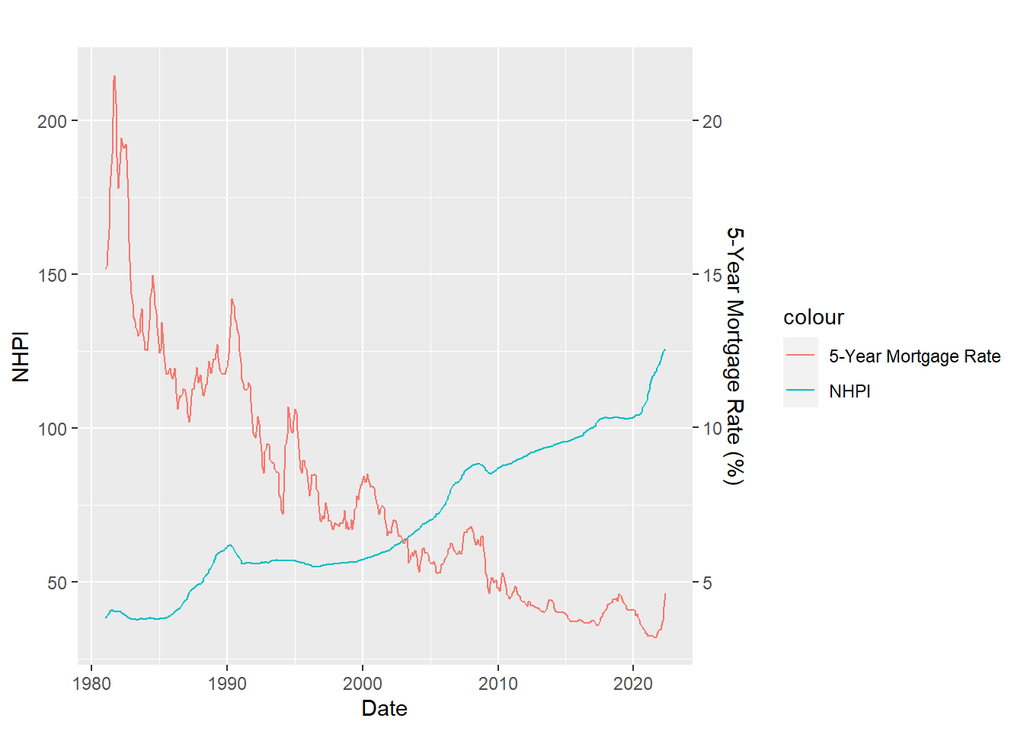

## 4 Conclusion

The best model is Model 3:

$$y = -173.47101 -6.41943 x_1 +2.01656
x_2 -0.00005 x_3 +0.20251 x_4 +0.89882 x_5 -0.00127
x_6$$

, where $x_5$ is $x_1^2$, and $x_6$ is the interaction between $x_3$ and $x_4$.

The analysis yielded some unexpected results regarding the effects of interest rates and immigration. When adjusted for CPI and earnings, immigration and the interest rate seem to affect the NHPI in the opposite directions that they are typically associated with in the literature. High immigration lowers NHPI, and high interest rate is associated with high NHPI. Simply limiting immigration may not result in lower housing prices.

The coefficient for the interaction between earnings and CPI is negative, which means the positive impact of earnings and CPI on NHPI is attenuated when these values change in the same direction. In other words, if changes in average wage stay in parity with CPI, housing prices tend to be a little lower. Thus, addressing the longstanding gap between wage increase and inflation may be a key step to lower the current rampant housing prices.

## References

[1] Durbin, J.; Watson, G. S. (1971). “Testing for serial correlation in least squares regression.III”. Biometrika. 58 (1): 1–19. doi:10.2307/2334313

[2] Newey, Whitney K; West, Kenneth D (1987). “A Simple, Positive Semi-definite, Heteroskedasticity and Autocorrelation Consistent Covariance Matrix” (PDF). Econometrica. 55 (3): 703–708. doi:10.2307/1913610. JSTOR 1913610.

[3] RBC-Pembina Location Matter series(2013). “Understanding the factors affecting home prices in the GTA.”, https://www.pembina.org/

[4] Statistics Canada. Table 10-10-0122-01 Financial market statistics, last Wednesday unless otherwise stated, Bank of Canada https://www150.statcan.gc.ca/t1/tbl1/en/tv.action?pid=1010012201

[5] Statistics Canada. Table 18-10-0205-01 New housing price index, monthly https://www150.statcan.gc.ca/t1/tbl1/en/tv.action?pid=1810020501

[6] Statistics Canada. Table 34-10-0145-01 Canada Mortgage and Housing Corporation, conventional mortgage lending rate, 5-year term https://www150.statcan.gc.ca/t1/tbl1/en/tv.action?pid=3410014501

[7] Statistics Canada. Table 17-10-0008-01 Estimates of the components of demographic growth, annual https://www150.statcan.gc.ca/t1/tbl1/en/tv.action?pid=1710000801

[8] Statistics Canada. Table 18-10-0004-01 Consumer Price Index, monthly, not seasonally adjusted https://www150.statcan.gc.ca/t1/tbl1/en/tv.action?pid=1810000401

[9] Statistics Canada. Table 14-10-0223-01 Employment and average weekly earnings (including overtime) for all employees by province and territory, monthly, seasonally adjusted https://www150.statcan.gc.ca/t1/tbl1/en/tv.action?pid=1410022301